# Practical Machine Learning - Movement Predictor

Eliezer Mitrani

## Summary

In this project we will construct a prediction machine, to predict the type of movement of a person according to the “Human Activity Recognition” dataset.

IMPORTANT NOTE: Some of the code will be hidden to guarantee the fluency of the lecture. You will find the complete code in the RMD file in the GitHub repository.

## Data Analysis

To archive our objective we will use the `Human Activity Recognition (HAR)` dataset. The (HAR) aims to identify the actions carried out by a person given a set of observations of him/herself and the surrounding environment.

### Loading the data

We will work with the pre-split dataset. Both, train and test, dataset can be found in: Train: https://d396qusza40orc.cloudfront.net/predmachlearn/pml-training.csv Test: https://d396qusza40orc.cloudfront.net/predmachlearn/pml-testing.csv

The datasets has a lot of DIV, NA and null variables. All this values has been interpreted as NA values. Also, we will set our seed as 2000.

```r
set.seed(2000)

subDir = "data" #This is only for the raw data file.
ifelse(!dir.exists(file.path("./", subDir)), dir.create(file.path("./", subDir)), FALSE) #this checks and create the data folder
```

```
[1] FALSE
```

```r
# download file from server
ifelse(!file.exists("./data/pml-training.csv"),
       download.file(url = "https://d396qusza40orc.cloudfront.net/predmachlearn/pml-training.csv",
                     destfile = "./data/pml-training.csv",
                     method = "libcurl"),FALSE)
```

```
[1] FALSE
```

```r
ifelse(!file.exists("./data/pml-testing.csv"),
       download.file(url = "https://d396qusza40orc.cloudfront.net/predmachlearn/pml-testing.csv",
                     destfile = "./data/pml-testing.csv",
                     method = "libcurl"),FALSE)
```

```
[1] FALSE
```

```r
train <- read.csv(file="./data/pml-training.csv", header=TRUE, na.strings=c("NA","#DIV/0!", ""))
test <- read.csv(file="./data/pml-testing.csv", header=TRUE, na.strings=c("NA","#DIV/0!", ""))
```

The train set has 19622 rows and 160 columns. The test set has 20 rows and 160 columns. But, many of this variables are NA values or irrelevant to the model. Let’s omit this variables

```r
# Delete columns with all missing values
trainingset<-train[,colSums(is.na(train)) == 0]
testingset <-test[,colSums(is.na(test)) == 0]

# Some variables are irrelevant to our current project: user_name, raw_timestamp_part_1, raw_timestamp_part_,2 cvtd_timestamp, new_window, and  num_window (columns 1 to 7). We can delete these variables.
trainingset   <-trainingset[,-c(1:7)]
testingset <-testingset[,-c(1:7)]
```

### Creating our Train and Test set

Our data comes with a “preset” train and test set. We will split our original train set in a new train and test set. And with the original test set we will be used as a out of the bag QUIZ set.

```r
set.seed(2000)

inTrain <- createDataPartition(y=trainingset$classe, p=0.75, list=FALSE)
subTrain <- trainingset[inTrain,]
subTest <- trainingset[-inTrain, ]
quizTest <- testingset
```

### Correlation:

As we can see, some of the variables has a strong correlation between. For example, there are some correlation berween the acceleration and the gyroscope variables. Maybe, we should try to use principal component analysis (PCA) to transform the data to a smaller sub-space where the new variable are uncorrelated with one another.

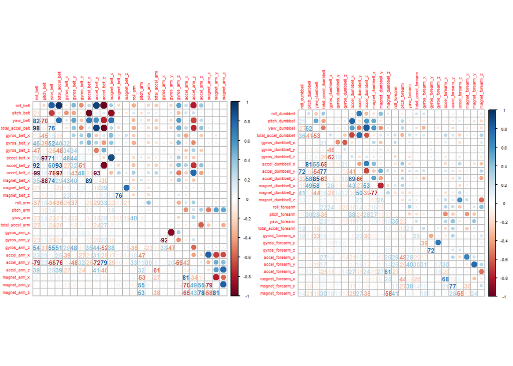

```r
M <- cor(subTrain[,(1:26)])
M2 <- cor(subTrain[,(27:52)])
par.before <- par()
par(mfrow=c(1,2), cex = 0.5)
corrplot.mixed(M, tl.pos="lt", tl.cex = 0.7, cl.cex = 0.7, addCoefasPercent = TRUE)
corrplot.mixed(M2, tl.pos="lt", tl.cex = 0.7, cl.cex = 0.7, addCoefasPercent = TRUE)
```

```r
par(cex = par.before)
dev.off()
```

## Building our Model

### 1. Tree model

Let’s start with a simple basal model. We will try to construct a simple tree using rpart including all the variables.

```r
tree1 <- train (classe~., method="rpart", data=subTrain)
print(tree1$finalModel)
```

```
n= 14718

node), split, n, loss, yval, (yprob)
      * denotes terminal node

 1) root 14718 10533 A (0.28 0.19 0.17 0.16 0.18)
   2) roll_belt< 130.5 13505  9333 A (0.31 0.21 0.19 0.18 0.11)
     4) pitch_forearm< -34.35 1179     6 A (0.99 0.0051 0 0 0) *
     5) pitch_forearm>=-34.35 12326  9327 A (0.24 0.23 0.21 0.2 0.12)
      10) magnet_dumbbell_y< 436.5 10380  7447 A (0.28 0.18 0.24 0.19 0.11)
        20) roll_forearm< 123.5 6501  3866 A (0.41 0.18 0.18 0.17 0.059) *
        21) roll_forearm>=123.5 3879  2597 C (0.077 0.17 0.33 0.23 0.19) *
      11) magnet_dumbbell_y>=436.5 1946   961 B (0.034 0.51 0.046 0.22 0.19) *
   3) roll_belt>=130.5 1213    13 E (0.011 0 0 0 0.99) *
```

[figure not shown]

```r
fancyRpartPlot(tree1$finalModel,cex=0.7)
```

As we an see, the roll belt is the most important variable to predict throwing the hips to the front (Class E), which makes sense. But our tree does not predict the class D (lowering the dumbbell only halfway). Let’s see the prediction capability of our model with the train and test data set.

```r
confusionMatrix(subTrain$classe, predict(tree1, newdata = subTrain))
```

```
Confusion Matrix and Statistics

          Reference
Prediction    A    B    C    D    E
         A 3808   66  298    0   13
         B 1186  985  677    0    0
         C 1196   89 1282    0    0
         D 1109  430  873    0    0
         E  381  376  749    0 1200

Overall Statistics

               Accuracy : 0.4943
                 95% CI : (0.4862, 0.5024)
    No Information Rate : 0.5218
    P-Value [Acc > NIR] : 1

                  Kappa : 0.3389
 Mcnemar's Test P-Value : NA

Statistics by Class:

                     Class: A Class: B Class: C Class: D Class: E
Sensitivity            0.4958  0.50617   0.3305       NA  0.98928
Specificity            0.9464  0.85413   0.8814   0.8361  0.88849
Pos Pred Value         0.9099  0.34586   0.4994       NA  0.44346
Neg Pred Value         0.6324  0.91904   0.7863       NA  0.99892
Prevalence             0.5218  0.13222   0.2636   0.0000  0.08242
Detection Rate         0.2587  0.06692   0.0871   0.0000  0.08153
Detection Prevalence   0.2843  0.19350   0.1744   0.1639  0.18386
Balanced Accuracy      0.7211  0.68015   0.6060       NA  0.93888
```

```r
confusionMatrix(subTest$classe, predict(tree1, newdata = subTest))
```

```
Confusion Matrix and Statistics

          Reference
Prediction    A    B    C    D    E
         A 1258   29  107    0    1
         B  379  317  253    0    0
         C  390   20  445    0    0
         D  332  150  322    0    0
         E  140  119  211    0  431

Overall Statistics

               Accuracy : 0.4998
                 95% CI : (0.4857, 0.5139)
    No Information Rate : 0.5096
    P-Value [Acc > NIR] : 0.917

                  Kappa : 0.3472
 Mcnemar's Test P-Value : NA

Statistics by Class:

                     Class: A Class: B Class: C Class: D Class: E
Sensitivity            0.5034  0.49921  0.33259       NA  0.99769
Specificity            0.9430  0.85196  0.88503   0.8361  0.89490
Pos Pred Value         0.9018  0.33404  0.52047       NA  0.47836
Neg Pred Value         0.6463  0.91960  0.77945       NA  0.99975
Prevalence             0.5096  0.12949  0.27284   0.0000  0.08809
Detection Rate         0.2565  0.06464  0.09074   0.0000  0.08789
Detection Prevalence   0.2845  0.19352  0.17435   0.1639  0.18373
Balanced Accuracy      0.7232  0.67558  0.60881       NA  0.94629
```

### 2. Random forest model

Our basal tree was very poor, but it’s a starting point. Let get the model further. We will start with a simple Random Forest model

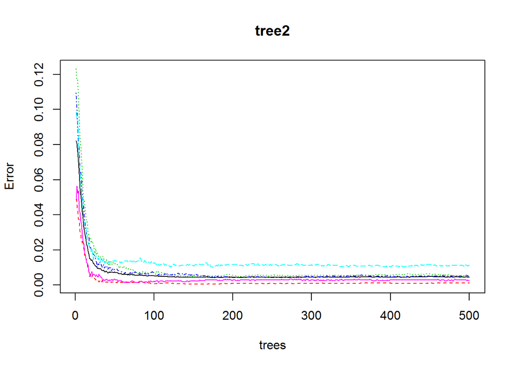

```r
tree2 <- randomForest(classe ~., data=subTrain, type="class")
plot(tree2)
```

500 decision trees or a forest has been built using the Random Forest algorithm based learning. We can plot the error rate across decision trees. The plot seems to indicate that after 100 decision trees, there is not a significant reduction in error rate.

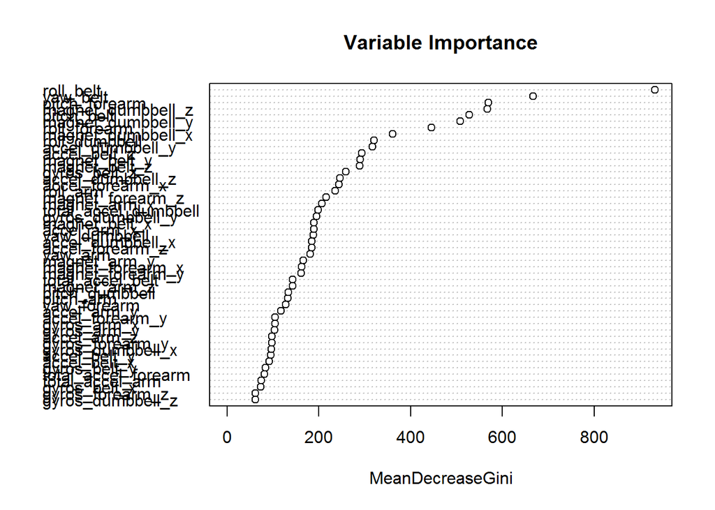

```r
# Variable Importance Plot
varImpPlot(tree2,
           sort = T,
           main="Variable Importance",
           n.var=50)
```

Now, we want to measure the accuracy of the Random Forest model. Some of the other model performance statistics are Kappa, Sensitivity, Specificity, etc.

```r
# Confussion matrix with the Train data
confusionMatrix(subTrain$classe, predict(tree2, newdata = subTrain))
```

```
Confusion Matrix and Statistics

          Reference
Prediction    A    B    C    D    E
         A 4185    0    0    0    0
         B    0 2848    0    0    0
         C    0    0 2567    0    0
         D    0    0    0 2412    0
         E    0    0    0    0 2706

Overall Statistics

               Accuracy : 1
                 95% CI : (0.9997, 1)
    No Information Rate : 0.2843
    P-Value [Acc > NIR] : < 2.2e-16

                  Kappa : 1
 Mcnemar's Test P-Value : NA

Statistics by Class:

                     Class: A Class: B Class: C Class: D Class: E
Sensitivity            1.0000   1.0000   1.0000   1.0000   1.0000
Specificity            1.0000   1.0000   1.0000   1.0000   1.0000
Pos Pred Value         1.0000   1.0000   1.0000   1.0000   1.0000
Neg Pred Value         1.0000   1.0000   1.0000   1.0000   1.0000
Prevalence             0.2843   0.1935   0.1744   0.1639   0.1839
Detection Rate         0.2843   0.1935   0.1744   0.1639   0.1839
Detection Prevalence   0.2843   0.1935   0.1744   0.1639   0.1839
Balanced Accuracy      1.0000   1.0000   1.0000   1.0000   1.0000
```

```r
# Confussion matrix with the Test data
confusionMatrix(subTest$classe, predict(tree2, newdata = subTest))
```

```
Confusion Matrix and Statistics

          Reference
Prediction    A    B    C    D    E
         A 1392    2    0    0    1
         B    5  942    2    0    0
         C    0    4  850    1    0
         D    0    0    7  796    1
         E    0    0    0    1  900

Overall Statistics

               Accuracy : 0.9951
                 95% CI : (0.9927, 0.9969)
    No Information Rate : 0.2849
    P-Value [Acc > NIR] : < 2.2e-16

                  Kappa : 0.9938
 Mcnemar's Test P-Value : NA

Statistics by Class:

                     Class: A Class: B Class: C Class: D Class: E
Sensitivity            0.9964   0.9937   0.9895   0.9975   0.9978
Specificity            0.9991   0.9982   0.9988   0.9981   0.9998
Pos Pred Value         0.9978   0.9926   0.9942   0.9900   0.9989
Neg Pred Value         0.9986   0.9985   0.9978   0.9995   0.9995
Prevalence             0.2849   0.1933   0.1752   0.1627   0.1839
Detection Rate         0.2838   0.1921   0.1733   0.1623   0.1835
Detection Prevalence   0.2845   0.1935   0.1743   0.1639   0.1837
Balanced Accuracy      0.9978   0.9960   0.9941   0.9978   0.9988
```

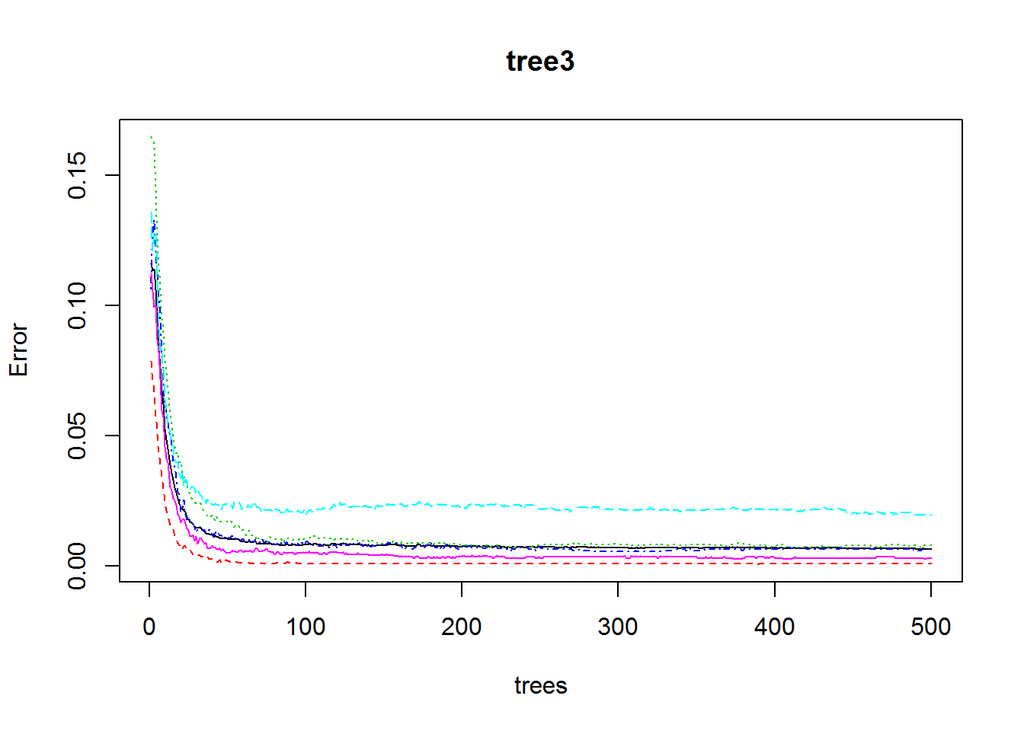

```r
tree3 <- randomForest(classe ~. -roll_belt -yaw_belt -total_accel_belt, data=subTrain, type="class")
plot(tree3)
```

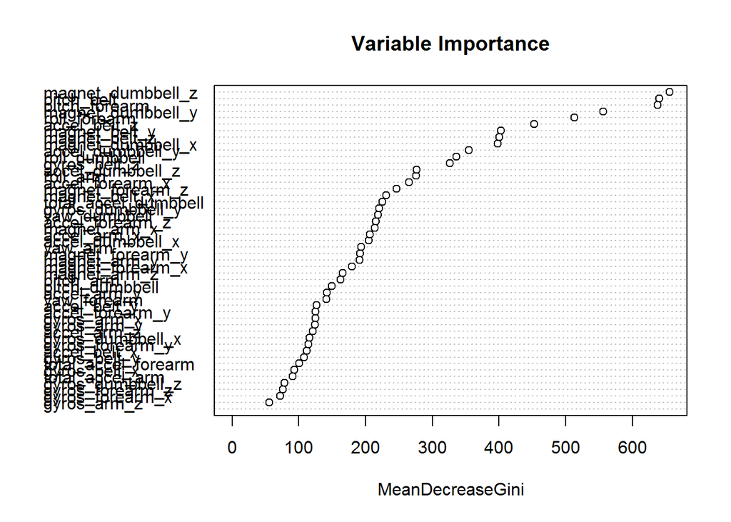

```r
varImpPlot(tree3,
           sort = T,
           main="Variable Importance",
           n.var=50)
```

```r
confusionMatrix(subTest$classe, predict(tree3, newdata = subTest))
```

```
Confusion Matrix and Statistics

          Reference
Prediction    A    B    C    D    E
         A 1392    2    0    0    1
         B    4  944    1    0    0
         C    0    7  848    0    0
         D    0    0   11  792    1
         E    0    0    0    1  900

Overall Statistics

               Accuracy : 0.9943
                 95% CI : (0.9918, 0.9962)
    No Information Rate : 0.2847
    P-Value [Acc > NIR] : < 2.2e-16

                  Kappa : 0.9928
 Mcnemar's Test P-Value : NA

Statistics by Class:

                     Class: A Class: B Class: C Class: D Class: E
Sensitivity            0.9971   0.9906   0.9860   0.9987   0.9978
Specificity            0.9991   0.9987   0.9983   0.9971   0.9998
Pos Pred Value         0.9978   0.9947   0.9918   0.9851   0.9989
Neg Pred Value         0.9989   0.9977   0.9970   0.9998   0.9995
Prevalence             0.2847   0.1943   0.1754   0.1617   0.1839
Detection Rate         0.2838   0.1925   0.1729   0.1615   0.1835
Detection Prevalence   0.2845   0.1935   0.1743   0.1639   0.1837
Balanced Accuracy      0.9981   0.9946   0.9922   0.9979   0.9988
```

As we can see, anything changes. The accuracy is still high.

## Generating the Quiz Submission

```r
predictfinal <- predict(tree3, quizTest, type="class")
table(predictfinal)
```

```
predictfinal
A B C D E
7 8 1 1 3
```

```r
# Write files for submission
pml_write_files = function(x){
  n = length(x)
  for(i in 1:n){
    filename = paste0("problem_id_",i,".txt")
    write.table(x[i],file=filename,quote=FALSE,row.names=FALSE,col.names=FALSE)
  }
}

pml_write_files(predictfinal)
```

## References

Velloso, E.; Bulling, A.; Gellersen, H.; Ugulino, W.; Fuks, H. Qualitative Activity Recognition of Weight Lifting Exercises. Proceedings of 4th International Conference in Cooperation with SIGCHI (Augmented Human ’13) . Stuttgart, Germany: ACM SIGCHI, 2013. Read more: http://groupware.les.inf.puc-rio.br/har#ixzz3vXuQBr7x

ESANN 2013 proceedings, European Symposium on Artificial Neural Networks, Computational Intelligence and Machine Learning. Bruges (Belgium), 24-26 April 2013, i6doc.com publ., ISBN 978-2-87419-081-0. Available from http://www.i6doc.com/en/livre/?GCOI=280011001310